# Serco Maintenance Event Modelling - Clean

```r
#Row count correct at 2933 - 9 blank asys
#JUL
#load the property data
rawPropertyDataJul <- read.csv("csv/Available_Bedrooms_And_Bedspaces_NW_2017-07-01.csv", skip=3, stringsAsFactors = FALSE)
#filter out rows that do not have a valid ASYS value
validAsysPropertyDataJul <- filter(rawPropertyDataJul, !is.na(as.numeric(as.character(rawPropertyDataJul$ASYS))),)
nrow(validAsysPropertyDataJul)
```

```
[1] 2934
```

```r
#Row count correct at 2934 - 18 blank asys
#AUG
#load the property data
rawPropertyDataAug <- read.csv("csv/Available_Bedrooms_And_Bedspaces_NW_2017-08-01.csv", skip=3, stringsAsFactors = FALSE)
#filter out rows that do not have a valid ASYS value
validAsysPropertyDataAug <- filter(rawPropertyDataAug, !is.na(as.numeric(as.character(rawPropertyDataAug$ASYS))),)
```

```
NAs introduced by coercion
```

```r
nrow(validAsysPropertyDataAug)
```

```
[1] 2942
```

```r
#Row count correct at 2942 - 8 blank asys and 1 marked 'DUPLICATE'
#SEP
#load the property data
rawPropertyDataSep <- read.csv("csv/Available_Bedrooms_And_Bedspaces_NW_2017-09-01.csv", skip=3, stringsAsFactors = FALSE)
#filter out rows that do not have a valid ASYS value
validAsysPropertyDataSep <- filter(rawPropertyDataSep, !is.na(as.numeric(as.character(rawPropertyDataSep$ASYS))),)
nrow(validAsysPropertyDataSep)
```

```
[1] 2935
```

```r
#Row count correct at 2935 - 18 blank asys
#OCT
#load the property data
rawPropertyDataOct <- read.csv("csv/Available_Bedrooms_And_Bedspaces_NW_2017-10-01.csv", skip=3, stringsAsFactors = FALSE)
#filter out rows that do not have a valid ASYS value
validAsysPropertyDataOct <- filter(rawPropertyDataOct, !is.na(as.numeric(as.character(rawPropertyDataOct$ASYS))),)
nrow(validAsysPropertyDataOct)
```

```
[1] 2953
```

```r
#Row count correct at 2953 - 5 blank asys
```

```r
#remove negative bedspaces
validAsysPropertyDataFeb$Negative.Bedspaces <- ifelse(validAsysPropertyDataFeb$Available.Bedspaces < 0, abs(validAsysPropertyDataFeb$Available.Bedspaces), 0)
validAsysPropertyDataFeb$Available.Bedspaces <- ifelse(validAsysPropertyDataFeb$Available.Bedspaces < 0, 0, validAsysPropertyDataFeb$Available.Bedspaces)
#remove negative bedrooms
validAsysPropertyDataFeb$Negative.Bedrooms <- ifelse(validAsysPropertyDataFeb$Available.Bedrooms < 0, abs(validAsysPropertyDataFeb$Available.Bedrooms), 0)
validAsysPropertyDataFeb$Available.Bedrooms <- ifelse(validAsysPropertyDataFeb$Available.Bedrooms < 0, 0, validAsysPropertyDataFeb$Available.Bedrooms)
#remove negative bedspaces
validAsysPropertyDataMar$Negative.Bedspaces <- ifelse(validAsysPropertyDataMar$Available.Bedspaces < 0, abs(validAsysPropertyDataMar$Available.Bedspaces), 0)
validAsysPropertyDataMar$Available.Bedspaces <- ifelse(validAsysPropertyDataMar$Available.Bedspaces < 0, 0, validAsysPropertyDataMar$Available.Bedspaces)
#remove negative bedrooms
validAsysPropertyDataMar$Negative.Bedrooms <- ifelse(validAsysPropertyDataMar$Available.Bedrooms < 0, abs(validAsysPropertyDataMar$Available.Bedrooms), 0)
validAsysPropertyDataMar$Available.Bedrooms <- ifelse(validAsysPropertyDataMar$Available.Bedrooms < 0, 0, validAsysPropertyDataMar$Available.Bedrooms)
#remove negative bedspaces
validAsysPropertyDataApr$Negative.Bedspaces <- ifelse(validAsysPropertyDataApr$Available.Bedspaces < 0, abs(validAsysPropertyDataApr$Available.Bedspaces), 0)
validAsysPropertyDataApr$Available.Bedspaces <- ifelse(validAsysPropertyDataApr$Available.Bedspaces < 0, 0, validAsysPropertyDataApr$Available.Bedspaces)
#remove negative bedrooms
validAsysPropertyDataApr$Negative.Bedrooms <- ifelse(validAsysPropertyDataApr$Available.Bedrooms < 0, abs(validAsysPropertyDataApr$Available.Bedrooms), 0)
validAsysPropertyDataApr$Available.Bedrooms <- ifelse(validAsysPropertyDataApr$Available.Bedrooms < 0, 0, validAsysPropertyDataApr$Available.Bedrooms)
#remove negative bedspaces
validAsysPropertyDataMay$Negative.Bedspaces <- ifelse(validAsysPropertyDataMay$Available.Bedspaces < 0, abs(validAsysPropertyDataMay$Available.Bedspaces), 0)
validAsysPropertyDataMay$Available.Bedspaces <- ifelse(validAsysPropertyDataMay$Available.Bedspaces < 0, 0, validAsysPropertyDataMay$Available.Bedspaces)
#remove negative bedrooms
validAsysPropertyDataMay$Negative.Bedrooms <- ifelse(validAsysPropertyDataMay$Available.Bedrooms < 0, abs(validAsysPropertyDataMay$Available.Bedrooms), 0)
validAsysPropertyDataMay$Available.Bedrooms <- ifelse(validAsysPropertyDataMay$Available.Bedrooms < 0, 0, validAsysPropertyDataMay$Available.Bedrooms)
#remove negative bedspaces
validAsysPropertyDataJun$Negative.Bedspaces <- ifelse(validAsysPropertyDataJun$Available.Bedspaces < 0, abs(validAsysPropertyDataJun$Available.Bedspaces), 0)
validAsysPropertyDataJun$Available.Bedspaces <- ifelse(validAsysPropertyDataJun$Available.Bedspaces < 0, 0, validAsysPropertyDataJun$Available.Bedspaces)
#remove negative bedrooms
validAsysPropertyDataJun$Negative.Bedrooms <- ifelse(validAsysPropertyDataJun$Available.Bedrooms < 0, abs(validAsysPropertyDataJun$Available.Bedrooms), 0)
validAsysPropertyDataJun$Available.Bedrooms <- ifelse(validAsysPropertyDataJun$Available.Bedrooms < 0, 0, validAsysPropertyDataJun$Available.Bedrooms)
#remove negative bedspaces
validAsysPropertyDataJul$Negative.Bedspaces <- ifelse(validAsysPropertyDataJul$Available.Bedspaces < 0, abs(validAsysPropertyDataJul$Available.Bedspaces), 0)
validAsysPropertyDataJul$Available.Bedspaces <- ifelse(validAsysPropertyDataJul$Available.Bedspaces < 0, 0, validAsysPropertyDataJul$Available.Bedspaces)
#remove negative bedrooms
validAsysPropertyDataJul$Negative.Bedrooms <- ifelse(validAsysPropertyDataJul$Available.Bedrooms < 0, abs(validAsysPropertyDataJul$Available.Bedrooms), 0)
validAsysPropertyDataJul$Available.Bedrooms <- ifelse(validAsysPropertyDataJul$Available.Bedrooms < 0, 0, validAsysPropertyDataJul$Available.Bedrooms)
#remove negative bedspaces
validAsysPropertyDataAug$Negative.Bedspaces <- ifelse(validAsysPropertyDataAug$Available.Bedspaces < 0, abs(validAsysPropertyDataAug$Available.Bedspaces), 0)
validAsysPropertyDataAug$Available.Bedspaces <- ifelse(validAsysPropertyDataAug$Available.Bedspaces < 0, 0, validAsysPropertyDataAug$Available.Bedspaces)
#remove negative bedrooms
validAsysPropertyDataAug$Negative.Bedrooms <- ifelse(validAsysPropertyDataAug$Available.Bedrooms < 0, abs(validAsysPropertyDataAug$Available.Bedrooms), 0)
validAsysPropertyDataAug$Available.Bedrooms <- ifelse(validAsysPropertyDataAug$Available.Bedrooms < 0, 0, validAsysPropertyDataAug$Available.Bedrooms)
#remove negative bedspaces
validAsysPropertyDataSep$Negative.Bedspaces <- ifelse(validAsysPropertyDataSep$Available.Bedspaces < 0, abs(validAsysPropertyDataSep$Available.Bedspaces), 0)
validAsysPropertyDataSep$Available.Bedspaces <- ifelse(validAsysPropertyDataSep$Available.Bedspaces < 0, 0, validAsysPropertyDataSep$Available.Bedspaces)
#remove negative bedrooms
validAsysPropertyDataSep$Negative.Bedrooms <- ifelse(validAsysPropertyDataSep$Available.Bedrooms < 0, abs(validAsysPropertyDataSep$Available.Bedrooms), 0)
validAsysPropertyDataSep$Available.Bedrooms <- ifelse(validAsysPropertyDataSep$Available.Bedrooms < 0, 0, validAsysPropertyDataSep$Available.Bedrooms)
#remove negative bedspaces
validAsysPropertyDataOct$Negative.Bedspaces <- ifelse(validAsysPropertyDataOct$Available.Bedspaces < 0, abs(validAsysPropertyDataOct$Available.Bedspaces), 0)
validAsysPropertyDataOct$Available.Bedspaces <- ifelse(validAsysPropertyDataOct$Available.Bedspaces < 0, 0, validAsysPropertyDataOct$Available.Bedspaces)
#remove negative bedrooms
validAsysPropertyDataOct$Negative.Bedrooms <- ifelse(validAsysPropertyDataOct$Available.Bedrooms < 0, abs(validAsysPropertyDataOct$Available.Bedrooms), 0)
validAsysPropertyDataOct$Available.Bedrooms <- ifelse(validAsysPropertyDataOct$Available.Bedrooms < 0, 0, validAsysPropertyDataOct$Available.Bedrooms)
```

*Pair faults with property data*

```r
#property 2912 rows
#events Feb 11304
propertyEventsFeb <- join(y = validAsysPropertyDataFeb, x = validAsysMaintenanceEventsFeb, by = c("ASYS"), type = "left", match = "all")
#11304 rows in the joined dataset - exactly the number of rows in the events dataset
propertyEventsMar <- join(y = validAsysPropertyDataMar, x = validAsysMaintenanceEventsMar, by = c("ASYS"), type = "left", match = "all")
propertyEventsApr <- join(y = validAsysPropertyDataApr, x = validAsysMaintenanceEventsApr, by = c("ASYS"), type = "left", match = "all")
propertyEventsMay <- join(y = validAsysPropertyDataMay, x = validAsysMaintenanceEventsMay, by = c("ASYS"), type = "left", match = "all")
propertyEventsJun <- join(y = validAsysPropertyDataJun, x = validAsysMaintenanceEventsJun, by = c("ASYS"), type = "left", match = "all")
propertyEventsJul <- join(y = validAsysPropertyDataJul, x = validAsysMaintenanceEventsJul, by = c("ASYS"), type = "left", match = "all")
propertyEventsAug <- join(y = validAsysPropertyDataAug, x = validAsysMaintenanceEventsAug, by = c("ASYS"), type = "left", match = "all")
propertyEventsSep <- join(y = validAsysPropertyDataSep, x = validAsysMaintenanceEventsSep, by = c("ASYS"), type = "left", match = "all")
propertyEventsOct <- join(y = validAsysPropertyDataOct, x = validAsysMaintenanceEventsOct, by = c("ASYS"), type = "left", match = "all")
propertyEvents <- rbind(propertyEventsFeb, propertyEventsMar, propertyEventsApr, propertyEventsMay, propertyEventsJun, propertyEventsJul, propertyEventsAug, propertyEventsSep, propertyEventsOct)
#looks like there are events that dont relate to a property and properties that have had no events (but the later wont be shown in the data set)
#find events with no 'Property.Category' which indicates the property details for the event were not found
eventsWithNoProperty <- filter(propertyEvents, is.na(propertyEvents$Property.Category))
#count number of events by ASYS number  (432 events in total across 25 properties) - we'll exclude them
eventsWithNoPropertyCount <- plyr::count(eventsWithNoProperty, "ASYS")
#exclude merged event row where there are no property details - should be 11304 - 432 = 10872
completeRows <- subset(propertyEvents, !is.na(propertyEvents$Property.Category),)
#There are some blank values in fields that need cleaning up
completeRows$Town[completeRows$Town == ""] <- "Unknown Town"
completeRows$Event.Accommodation.Type[completeRows$Event.Accommodation.Type == ""] <- "Unknown Accommodation Type"
completeRows$Occupancy.Type[completeRows$Occupancy.Type == ""] <- "Unknown Occupancy Type"
```

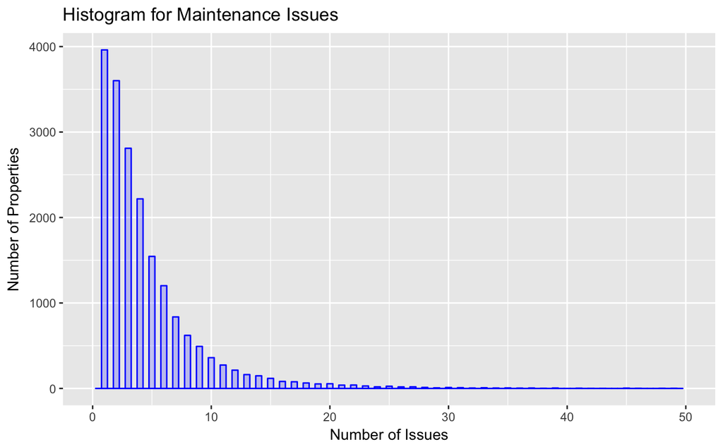

```r
#Need to look at properties MONTHLY - will give us more observations (dont necessarily want to view months tho - we are working with property types, not individual properties).
#CREATE A HISTOGRAM OF NUMBER OF PROPERTIES WITH NUMBER OF FAULTS - MAKE A QUICK SUMMARY BY ASYS
#This will create faults per property per month - loses us some data
propertyEventCount <- plyr::count(completeRows, c("ASYS", "Fault.Identified.Month.Number"))
qplot(propertyEventCount$freq,
      geom="histogram",
      binwidth = 0.5,
      main = "Histogram for Maintenance Issues",
      xlab = "Number of Issues",
      ylab = "Number of Properties",
      fill=I("blue"),
      col=I("blue"),
      alpha=I(.2),
      xlim=c(0,50))
```

```r
#We have a heavily right skewed distribution so we might need to balance it before we can predict.
#See: https://stats.stackexchange.com/questions/107610/what-is-the-reason-the-log-transformation-is-used-with-right-skewed-distribution
```

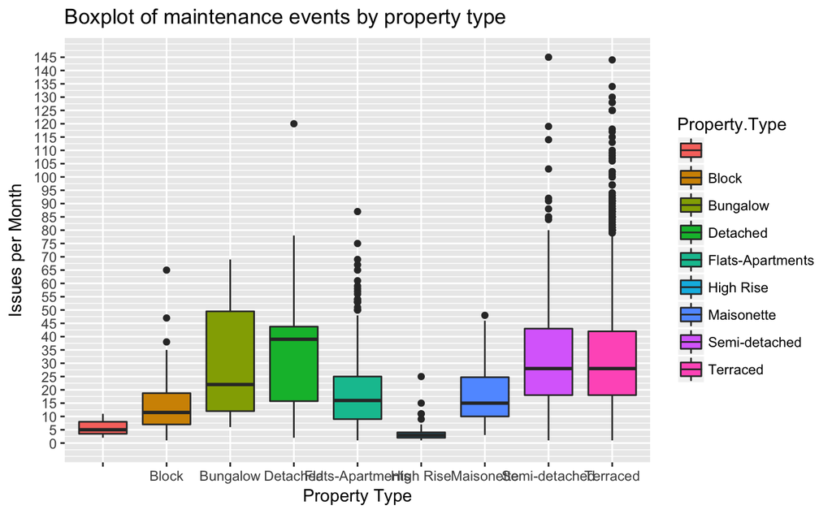

```r
#Using box plots to explore things that might be related to number of issues,
#We want the number of errors by property type - which is just a row count
#y = count(completeRowsFeb, c('Ward', 'Property.Type'))
#y
y = count(completeRows, c('ASYS', 'Property.Type'))
#Number of errors by property type
propertyTypeBP1 <- ggplot(y, aes(x = Property.Type, y = freq, fill=Property.Type)) +
        scale_x_discrete(name = "Property Type") +
        scale_y_continuous(name = "Issues per Month", breaks = seq(0, 145, 5), limits=c(0, 145)) +
        ggtitle("Boxplot of maintenance events by property type") +
        geom_boxplot()
propertyTypeBP1
```

Looks like there are in general more problems with detached properties. Flats-Apartments are generally fine but there are a couple of problem properties. There are a large number of high fault problem properties that are Terraced.

WE’LL PROBABLY NEED TO ADD IN ALL THE PROPERTIES THAT DON’T HAVE AN ERROR OTHERWISE IT WILL ALWAYS SKEW WHEN LEARNING.

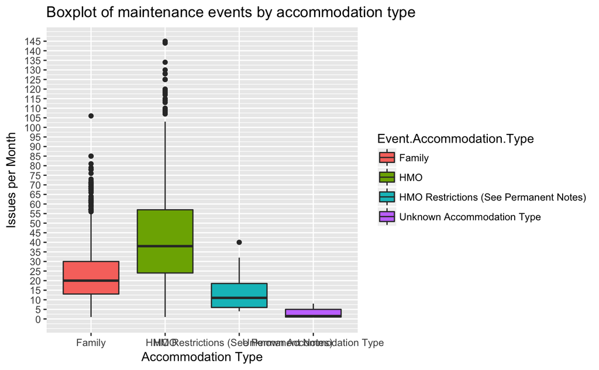

```r
y = count(completeRows, c('ASYS', 'Event.Accommodation.Type'))
#Number of errors by property type
accomTypeBP1 <- ggplot(y, aes(x = Event.Accommodation.Type, y = freq, fill=Event.Accommodation.Type)) +
        scale_x_discrete(name = "Accommodation Type") +
        scale_y_continuous(name = "Issues per Month", breaks = seq(0, 145, 5), limits=c(0, 145)) +
        ggtitle("Boxplot of maintenance events by accommodation type") +
        geom_boxplot()
accomTypeBP1
```

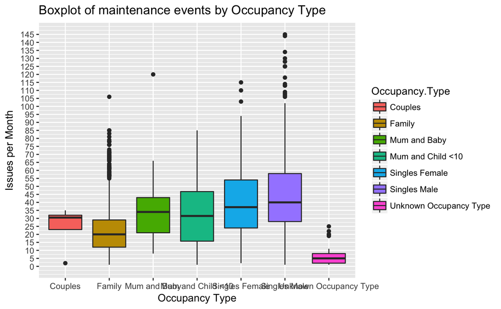

```r
y = count(completeRows, c('ASYS', 'Occupancy.Type'))
#Number of errors by property type
OccupancyTypeBP1 <- ggplot(y, aes(x = Occupancy.Type, y = freq, fill=Occupancy.Type)) +
        scale_x_discrete(name = "Occupancy Type") +
        scale_y_continuous(name = "Issues per Month", breaks = seq(0, 145, 5), limits=c(0, 145)) +
        ggtitle("Boxplot of maintenance events by Occupancy Type") +
        geom_boxplot()
OccupancyTypeBP1
```

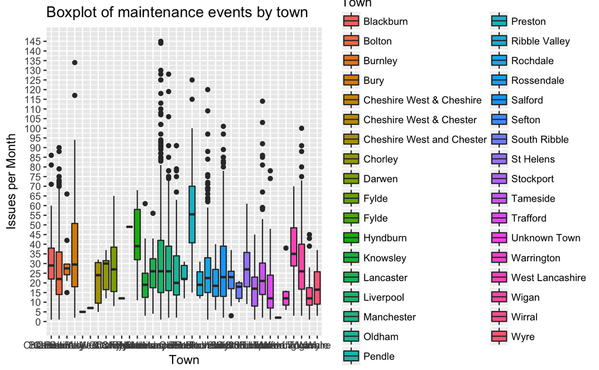

```r
y = count(completeRows, c('ASYS', 'Town'))
#Number of errors by property type
TownBP1 <- ggplot(y, aes(x = Town, y = freq, fill=Town)) +
        scale_x_discrete(name = "Town") +
        scale_y_continuous(name = "Issues per Month", breaks = seq(0, 145, 5), limits=c(0, 145)) +
        ggtitle("Boxplot of maintenance events by town") +
        geom_boxplot()
TownBP1
```

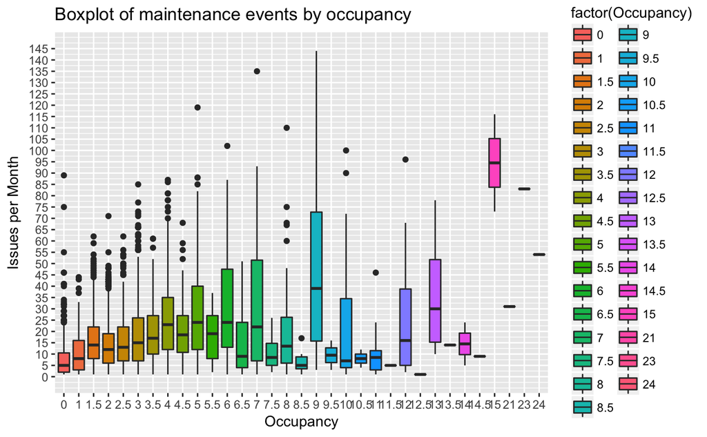

```r
y = count(completeRows, c('ASYS', 'Occupancy'))
#Number of errors by occupancy
OccupancyBP1 <- ggplot(y, aes(x = factor(Occupancy), y = freq, fill=factor(Occupancy))) +
        scale_x_discrete(name = "Occupancy") +
        scale_y_continuous(name = "Issues per Month", breaks = seq(0, 145, 5), limits=c(0, 145)) +
        ggtitle("Boxplot of maintenance events by occupancy") +
        geom_boxplot()
OccupancyBP1
```

*Create ML Data Set - Filter out attributes that wont add anything to our model*

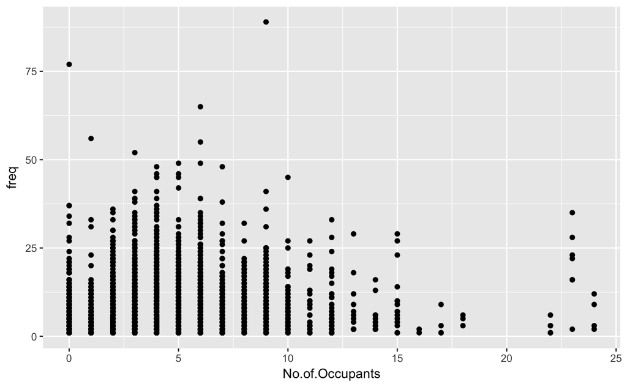

```r
#Group by ASYS and month so we have events per property per month.
#should give 19185 rows - but gives 19342 - some property details have changed 'in month'.
#I think these are still valid observations that should be kept.
mlSet = count(completeRows, c(
'ASYS',
'Property.Status.at.Capture',
'No.of.Occupants',
'Event.Accommodation.Type',
'Property.Category',
'Town',
'Property.Type',
'Accommodation.Type',
'Occupancy.Type',
'Property.Status',
'Bed.rooms',
'Bedspaces',
'Active.Service.Users',
'Active.Service.Users.Plus',
'Available.Bedrooms',
'Available.Bedspaces',
'Occupancy',
'Rent',
'Lease.Type',
'No.Area.Bedrooms',
'Total.Calculated.Bedspaces',
'No.Area.Lounges',
'No.Area.Dining.Rooms',
'No.Area.Kitchens',
'No.Area.Kitchen.Diners',
'No.Area.Utilities',
'No.Area.W.C.s',
'No.Area.Bathrooms',
'No.Area.Ensuites',
'No.Floors',
'Negative.Bedspaces',
'Negative.Bedrooms',
'Fault.Identified.Month.Number'
))
#remove the property identifier and the month - we dont need them and they may influence learning
mlSet <- mlSet[ , names(mlSet) != "ASYS"]
mlSet <- mlSet[ , names(mlSet) != "Fault.Identified.Month.Number"]
#Removed 'Landlord.Company.Name' from the dataset because it generates lots of columns and doesn't seem to be very important for predicting faults.
#!Removed Ward - because its troublesome - might bring it back in later
#mlSet
ggplot(mlSet, aes(x=No.of.Occupants, y=freq)) + geom_point()
```

## Starting Machine Learning

We want to use linear regression and predict the number of issues based on location, occupancy, occupant type and property type with 85% accuracy.

```r
#basic stats
summary(mlSet)
```

```
 Property.Status.at.Capture No.of.Occupants  Event.Accommodation.Type Property.Category
 Length:19342               Min.   : 0.000   Length:19342             Length:19342
 Class :character           1st Qu.: 3.000   Class :character         Class :character
 Mode  :character           Median : 4.000   Mode  :character         Mode  :character
                            Mean   : 3.784
                            3rd Qu.: 5.000
                            Max.   :24.000

     Town           Property.Type      Accommodation.Type Occupancy.Type     Property.Status
 Length:19342       Length:19342       Length:19342       Length:19342       Length:19342
 Class :character   Class :character   Class :character   Class :character   Class :character
 Mode  :character   Mode  :character   Mode  :character   Mode  :character   Mode  :character




   Bed.rooms        Bedspaces      Active.Service.Users Active.Service.Users.Plus Available.Bedrooms
 Min.   : 0.000   Min.   : 0.000   Min.   : 0.000       Min.   : 0.000            Min.   : 0.00000
 1st Qu.: 2.000   1st Qu.: 3.000   1st Qu.: 3.000       1st Qu.: 3.000            1st Qu.: 0.00000
 Median : 3.000   Median : 4.000   Median : 4.000       Median : 4.000            Median : 0.00000
 Mean   : 3.084   Mean   : 4.536   Mean   : 3.747       Mean   : 3.827            Mean   : 0.09896
 3rd Qu.: 4.000   3rd Qu.: 6.000   3rd Qu.: 5.000       3rd Qu.: 5.000            3rd Qu.: 0.00000
 Max.   :24.000   Max.   :29.000   Max.   :24.000       Max.   :24.000            Max.   :15.00000

 Available.Bedspaces   Occupancy          Rent            Lease.Type        No.Area.Bedrooms
 Min.   : 0.0000     Min.   : 0.000   Length:19342       Length:19342       Min.   : 0.000
 1st Qu.: 0.0000     1st Qu.: 2.000   Class :character   Class :character   1st Qu.: 2.000
 Median : 0.0000     Median : 3.000   Mode  :character   Mode  :character   Median : 3.000
 Mean   : 0.9913     Mean   : 3.209                                         Mean   : 3.085
 3rd Qu.: 2.0000     3rd Qu.: 4.000                                         3rd Qu.: 4.000
 Max.   :25.0000     Max.   :24.000                                         Max.   :24.000

 Total.Calculated.Bedspaces No.Area.Lounges  No.Area.Dining.Rooms No.Area.Kitchens
 Min.   : 0.000             Min.   :0.0000   Min.   :0.0000       Min.   :0.0000
 1st Qu.: 2.000             1st Qu.:1.0000   1st Qu.:0.0000       1st Qu.:1.0000
 Median : 4.000             Median :1.0000   Median :0.0000       Median :1.0000
 Mean   : 4.212             Mean   :0.9122   Mean   :0.1027       Mean   :0.8438
 3rd Qu.: 6.000             3rd Qu.:1.0000   3rd Qu.:0.0000       3rd Qu.:1.0000
 Max.   :34.500             Max.   :2.0000   Max.   :2.0000       Max.   :8.0000
 NA's   :2
 No.Area.Kitchen.Diners No.Area.Utilities No.Area.W.C.s    No.Area.Bathrooms No.Area.Ensuites
 Min.   :0.0000         Min.   :0.0000    Min.   :0.0000   Min.   :0.000     Min.   :0.00000
 1st Qu.:0.0000         1st Qu.:0.0000    1st Qu.:0.0000   1st Qu.:1.000     1st Qu.:0.00000
 Median :0.0000         Median :0.0000    Median :0.0000   Median :1.000     Median :0.00000
 Mean   :0.1837         Mean   :0.1197    Mean   :0.1715   Mean   :1.119     Mean   :0.04234
 3rd Qu.:0.0000         3rd Qu.:0.0000    3rd Qu.:0.0000   3rd Qu.:1.000     3rd Qu.:0.00000
 Max.   :2.0000         Max.   :3.0000    Max.   :7.0000   Max.   :8.000     Max.   :9.00000

   No.Floors     Negative.Bedspaces Negative.Bedrooms      freq
 Min.   :0.000   Min.   :0.0000     Min.   : 0.0000   Min.   : 1.000
 1st Qu.:2.000   1st Qu.:0.0000     1st Qu.: 0.0000   1st Qu.: 2.000
 Median :2.000   Median :0.0000     Median : 1.0000   Median : 3.000
 Mean   :1.917   Mean   :0.2825     Mean   : 0.8767   Mean   : 4.537
 3rd Qu.:2.000   3rd Qu.:0.0000     3rd Qu.: 1.0000   3rd Qu.: 6.000
 Max.   :5.000   Max.   :7.0000     Max.   :13.0000   Max.   :89.000
```

```r
#complete roles - no output here means all the rows have values in every column
mlSet <- mlSet[complete.cases(mlSet),]
mlSet[!complete.cases(mlSet),]
```

| Property.Status.at.Capture | No.of.Occupants | Event.Accommodation.Type | Property.Category | Town | Property.Type | Accommodation.Type | Occupancy.Type | Property.Status | Bed.rooms | Bedspaces | Active.Service.Users | Active.Service.Users.Plus | Available.Bedrooms | Available.Bedspaces | Occupancy | Rent | Lease.Type | No.Area.Bedrooms | Total.Calculated.Bedspaces | No.Area.Lounges | No.Area.Dining.Rooms | No.Area.Kitchens | No.Area.Kitchen.Diners | No.Area.Utilities | No.Area.W.C.s | No.Area.Bathrooms | No.Area.Ensuites | No.Floors | Negative.Bedspaces | … |
| --- | --- | --- | --- | --- | --- | --- | --- | --- | --- | --- | --- | --- | --- | --- | --- | --- | --- | --- | --- | --- | --- | --- | --- | --- | --- | --- | --- | --- | --- | --- |

The variable ‘mlSet’ not contains all the data you need to start buidling models.